# hw02

Brandon Huang

### 2. Importing the Data

```r
colClasses = c(
  "character",
  "character",
  "factor",
  "character",
  "real",
  rep("integer", 19)
)
```

```r
col_brandon = list(
  col_character(),
  col_character(),
  col_factor(c('C', 'PF', 'PG', 'SF', 'SG')),
  col_character(),
  col_double(),
  rep(col_integer(), 19)
  )
```

```r
#read_csv - readr
dat2 <- read_csv("/Users/brandon/Desktop/stat133/stat133-hws-fall17/hw02/data/nba2017-player-statistics.csv", col_types = col_brandon)
dat2$Experience <- replace(dat2$Experience, dat2$Experience == "R", "0")
dat2$Experience <- as.integer(dat2$Experience)
#???ASK TA"nba2017-player-statistics.csv", col_types?????????????

str(dat2)
```

```
## Classes 'tbl_df', 'tbl' and 'data.frame':    441 obs. of  6 variables:
##  $ Player    : chr  "Al Horford" "Amir Johnson" "Avery Bradley" "Demetrius Jackson" ...
##  $ Team      : chr  "BOS" "BOS" "BOS" "BOS" ...
##  $ Position  : Factor w/ 5 levels "C","PF","PG",..: 1 2 5 3 4 3 4 5 4 2 ...
##  $ Experience: int  9 11 6 0 9 5 4 2 0 6 ...
##  $ Salary    : num  26540100 12000000 8269663 1450000 1410598 ...
##  $ Rank      : int  4 6 5 15 11 1 3 13 8 10 ...
##  - attr(*, "problems")=Classes 'tbl_df', 'tbl' and 'data.frame': 441 obs. of  5 variables:
##   ..$ row     : int  1 2 3 4 5 6 7 8 9 10 ...
##   ..$ col     : chr  NA NA NA NA ...
##   ..$ expected: chr  "6 columns" "6 columns" "6 columns" "6 columns" ...
##   ..$ actual  : chr  "24 columns" "24 columns" "24 columns" "24 columns" ...
##   ..$ file    : chr  "'/Users/brandon/Desktop/stat133/stat133-hws-fall17/hw02/data/nba2017-player-statistics.csv'" "'/Users/brandon/Desktop/stat133/stat133-hws-fall17/hw02/data/nba2017-player-statistics.csv'" "'/Users/brandon/Desktop/stat133/stat133-hws-fall17/hw02/data/nba2017-player-statistics.…
##  - attr(*, "spec")=List of 2
##   ..$ cols   :List of 6
##   .. ..$ Player    : list()
##   .. .. ..- attr(*, "class")= chr  "collector_character" "collector"
##   .. ..$ Team      : list()
##   .. .. ..- attr(*, "class")= chr  "collector_character" "collector"
##   .. ..$ Position  :List of 3
##   .. .. ..$ levels    : chr  "C" "PF" "PG" "SF" ...
##   .. .. ..$ ordered   : logi FALSE
##   .. .. ..$ include_na: logi FALSE
##   .. .. ..- attr(*, "class")= chr  "collector_factor" "collector"
##   .. ..$ Experience: list()
##   .. .. ..- attr(*, "class")= chr  "collector_character" "collector"
##   .. ..$ Salary    : list()
##   .. .. ..- attr(*, "class")= chr  "collector_double" "collector"
##   .. ..$ Rank      : list()
##   .. .. ..- attr(*, "class")= chr  "collector_integer" "collector"
##   ..$ default: list()
##   .. ..- attr(*, "class")= chr  "collector_guess" "collector"
##   ..- attr(*, "class")= chr "col_spec"
```

```r
#read.csv - base
dat <- read.csv(file = "/Users/brandon/Desktop/stat133/stat133-hws-fall17/hw02/data/nba2017-player-statistics.csv", stringsAsFactors = FALSE, colClasses = colClasses)
dat$Experience <- replace(dat$Experience, dat$Experience == "R", "0")
dat$Experience <- as.integer(dat$Experience)
str(dat)
```

```
## 'data.frame':    441 obs. of  24 variables:
##  $ Player      : chr  "Al Horford" "Amir Johnson" "Avery Bradley" "Demetrius Jackson" ...
##  $ Team        : chr  "BOS" "BOS" "BOS" "BOS" ...
##  $ Position    : Factor w/ 5 levels "C","PF","PG",..: 1 2 5 3 4 3 4 5 4 2 ...
##  $ Experience  : int  9 11 6 0 9 5 4 2 0 6 ...
##  $ Salary      : num  26540100 12000000 8269663 1450000 1410598 ...
##  $ Rank        : int  4 6 5 15 11 1 3 13 8 10 ...
##  $ Age         : int  30 29 26 22 31 27 26 21 20 29 ...
##  $ GP          : int  68 80 55 5 47 76 72 29 78 78 ...
##  $ GS          : int  68 77 55 0 0 76 72 0 20 6 ...
##  $ MIN         : int  2193 1608 1835 17 538 2569 2335 220 1341 1232 ...
##  $ FGM         : int  379 213 359 3 95 682 333 25 192 114 ...
##  $ FGA         : int  801 370 775 4 232 1473 720 58 423 262 ...
##  $ Points3     : int  86 27 108 1 39 245 157 12 46 45 ...
##  $ Points3_atts: int  242 66 277 1 111 646 394 35 135 130 ...
##  $ Points2     : int  293 186 251 2 56 437 176 13 146 69 ...
##  $ Points2_atts: int  559 304 498 3 121 827 326 23 288 132 ...
##  $ FTM         : int  108 67 68 3 33 590 176 6 85 26 ...
##  $ FTA         : int  135 100 93 6 41 649 217 9 124 37 ...
##  $ OREB        : int  95 117 65 2 17 43 48 6 45 60 ...
##  $ DREB        : int  369 248 269 2 68 162 367 20 175 213 ...
##  $ AST         : int  337 140 121 3 33 449 155 4 64 71 ...
##  $ STL         : int  52 52 68 0 9 70 72 10 35 26 ...
##  $ BLK         : int  87 62 11 0 7 13 23 2 18 17 ...
##  $ TO          : int  116 77 88 0 25 210 79 4 68 39 ...
```

### 4. Performance of Players

```r
#new statistics
Missed_FG = dat$FGA - dat$FGM
Missed_FT = dat$FTA - dat$FTM
PTS = dat$Points3 * 3 + dat$Points2 * 2  + dat$FTM
REB = dat$OREB + dat$DREB
MPG = dat$MIN/ dat$GP


#add columns
dat <- cbind(dat, Missed_FG)
dat <- cbind(dat, Missed_FT)
dat <- cbind(dat, PTS)
dat <- cbind(dat, REB)
dat <- cbind(dat, MPG)
```

```r
EFF = ((dat$PTS + dat$REB + dat$AST + dat$STL + dat$BLK - dat$Missed_FG - dat$Missed_FT - dat$TO) / dat$GP)

summary(EFF)
```

```
##    Min. 1st Qu.  Median    Mean 3rd Qu.    Max.
##  -0.600   5.452   9.090  10.137  13.247  33.840
```

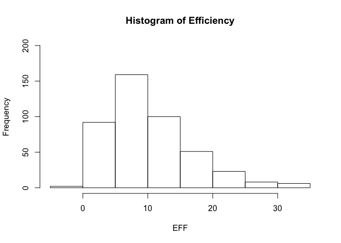

```r
dat <- cbind(dat, EFF)

hist(dat$EFF, main = "Histogram of Efficiency", xlab = 'EFF', ylab = 'Frequency', ylim = c(0, 200))
```

```r
#top then players by EFF
head(dat[order(dat$EFF, decreasing = TRUE), c(1, 2, 5, 30)], 10)
```

```
##                    Player Team   Salary      EFF
## 305     Russell Westbrook  OKC 26540100 33.83951
## 256          James Harden  HOU 26540100 32.34568
## 355         Anthony Davis  NOP 22116750 31.16000
## 28           LeBron James  CLE 30963450 30.97297
## 404    Karl-Anthony Towns  MIN  5960160 30.32927
## 228          Kevin Durant  GSW 26540100 30.19355
## 74  Giannis Antetokounmpo  MIL  2995421 28.37500
## 359      DeMarcus Cousins  NOP 16957900 27.94118
## 110          Jimmy Butler  CHI 17552209 25.60526
## 119      Hassan Whiteside  MIA 22116750 25.36364
```

```r
#players with negative EFF
dat[dat$EFF < 0, 1]
```

```
## [1] "Patricio Garino"
```

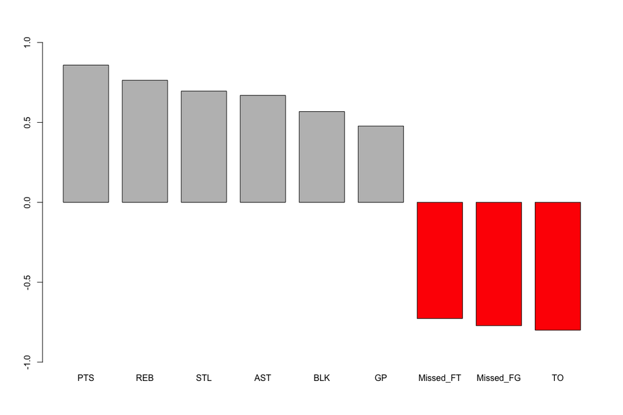

```r
#correlation between EFF and variable
co <- c(PTS = cor(dat$EFF, dat$PTS),
REB = cor(dat$EFF, dat$REB),
AST = cor(dat$EFF, dat$AST),
STL = cor(dat$EFF, dat$STL),
BLK = cor(dat$EFF, dat$BLK),
Missed_FG = cor(dat$EFF, dat$Missed_FG) * -1,
Missed_FT = cor(dat$EFF, dat$Missed_FT) * -1,
TO = cor(dat$EFF, dat$TO) * -1,
GP = cor(dat$EFF, dat$GP))

co <- sort(co, decreasing = TRUE)

barplot(co, space = 0.3, col = ifelse(co < 0, 'red', 'grey'), ylim = c(-1,1))
```

### 5. Efficiency and Salary

```r
#plotting EFF (x) and Salary (y), include lowess smooth line, compute linear correlation coeffecient

mil_salary <- dat$Salary/1000000

plot(dat$EFF, mil_salary, main = "Scatterplot of Efficiency and Salary", xlab = 'Efficiency', ylab = 'Salary (in millions)')

cor(dat$EFF, mil_salary)
```

```
## [1] 0.655624
```

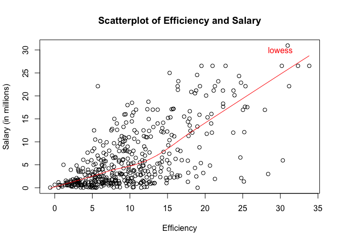

```r
lines(lowess(dat$EFF, mil_salary), col= 'red')
text(30, 30, 'lowess', col = 'red')
```

What can you say about the relationship between Efficiency and Salary? The relationship between Efficiency and Salary is that if efficiency goes up, salary is most likely to follow. The correlation is 0.655 which indicates they are positively correlated.

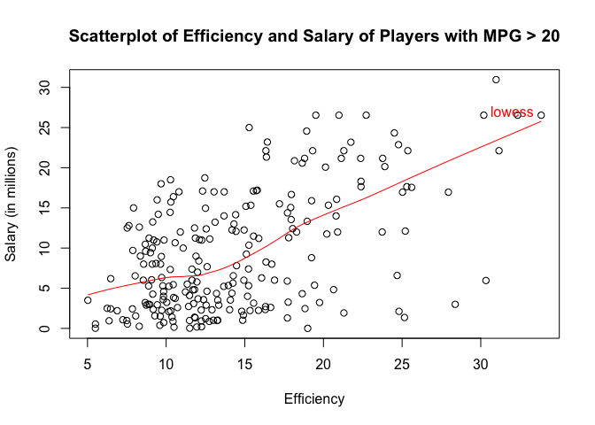

```r
#scatterplot for MPG > 20
players2 <- dat[dat$MPG > 20, ]
mil_salary_players2 <- players2$Salary/1000000

plot(players2$EFF, mil_salary_players2, main = "Scatterplot of Efficiency and Salary of Players with MPG > 20", xlab = 'Efficiency', ylab = 'Salary (in millions)')

lines(lowess(players2$EFF, mil_salary_players2), col= 'red')
text(32, 27, 'lowess', col = 'red')
```

```r
cor(players2$EFF, mil_salary_players2)
```

```
## [1] 0.5367224
```

What can you say about the relationship between these two variables for the “more established players”? With MPG > 20 taken into account, the correlation is less than the relationship between efficency and salary of all players. However it is still positive which indicates a positive relationship between the two. If efficiency goes up, salary is likely to go up too. I think that there is a difference in correlation between the two because players with more experience’s payrates do not fluctuate as much as the total with rookies.

### 6. Comments and Reflections

Using read_csv was hard because a lot of the syntax changes and there were small things like col_factor you have to include the levels. I needed help on the col_factor and csv_read part. I did not know I had to manually put -1 into the Missed Field Goal and Missed Free Throw. The most time consuming part was read_csv. I am not sure if I fully understand the interpretation of the graphs for scatterplots of efficiency and salary of players. There wasn’t any frustrating and figuring out the csv_read through a friend was the best part.